# Project Python Foundations: FoodHub Data Analysis

### **Question 9**: What percentage of the orders cost more than 20 dollars? [2 marks]

```python
df.loc[df['cost_of_the_order']>20]
```

|  | order_id | customer_id | restaurant_name | cuisine_type | cost_of_the_order | day_of_the_week | rating | food_preparation_time | delivery_time |
| --- | --- | --- | --- | --- | --- | --- | --- | --- | --- |
| 0 | 1477147 | 337525 | Hangawi | Korean | 30.75 | Weekend | Not given | 25 | 20 |
| 3 | 1477334 | 106968 | Blue Ribbon Fried Chicken | American | 29.20 | Weekend | 3 | 25 | 15 |
| 5 | 1477224 | 147468 | Tamarind TriBeCa | Indian | 25.22 | Weekday | 3 | 20 | 24 |
| 12 | 1476966 | 129969 | Blue Ribbon Fried Chicken | American | 24.30 | Weekend | 5 | 23 | 17 |
| 17 | 1477373 | 139885 | Blue Ribbon Sushi Izakaya | Japanese | 33.03 | Weekend | Not given | 21 | 22 |
| ... | ... | ... | ... | ... | ... | ... | ... | ... | ... |
| 1884 | 1477437 | 304993 | Shake Shack | American | 31.43 | Weekend | 3 | 31 | 24 |
| 1885 | 1477550 | 97324 | Shake Shack | American | 29.05 | Weekday | 4 | 27 | 29 |
| 1892 | 1477473 | 97838 | Han Dynasty | Chinese | 29.15 | Weekend | Not given | 29 | 21 |
| 1893 | 1476701 | 292602 | Chipotle Mexican Grill $1.99 Delivery | Mexican | 22.31 | Weekend | 5 | 31 | 17 |
| 1895 | 1477819 | 35309 | Blue Ribbon Sushi | Japanese | 25.22 | Weekday | Not given | 31 | 24 |

555 rows × 9 columns

```python
sns.boxplot(data=df, x='cost_of_the_order');
```

[output not shown]

#### Observations:

- *555 of the 1,898 orders cost more than \$20*
- *This is approximately 29.2% of the orders in the data set.*

### **Question 10**: What is the mean order delivery time? [1 mark]

```python
df['delivery_time'].describe()
```

```
count    1898.000000
mean       24.161749
std         4.972637
min        15.000000
25%        20.000000
50%        25.000000
75%        28.000000
max        33.000000
Name: delivery_time, dtype: float64
```

#### Observations:

- *The mean order delivery time is approximately 24 minutes and 10 seconds.*

### **Question 11:** The company has decided to give 20% discount vouchers to the top 5 most frequent customers. Find the IDs of these customers and the number of orders they placed. [1 mark]

```python
df['customer_id'].value_counts()[0:5]
```

```
52832     13
47440     10
83287      9
250494     8
259341     7
Name: customer_id, dtype: int64
```

#### Observations:

- *The top 5 most frequent customers are listed above. The top 3 most frequent have a lower number as part of their customer ID number indicating that they registered earlier and are more tenured in terms of customer loyalty when compared to the last two customers on this list who registered later.*
- *It would be interesting to further look at the top three customers' choice of restaurant and cuisine type to see if there is any correlation.*

### **Question 12**: Perform a multivariate analysis to explore relationships between the important variables in the dataset. (It is a good idea to explore relations between numerical variables as well as relations between numerical and categorical variables) [10 marks]

#### *Relationship between cuisine type, day of the week (weekday vs. weekend) and delivery time:*

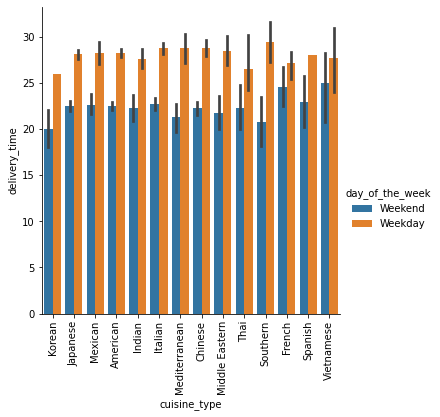

```python
sns.catplot(x='cuisine_type', y='delivery_time', data=df, kind="bar", hue='day_of_the_week')
plt.xticks(rotation=90)
plt.show()
```

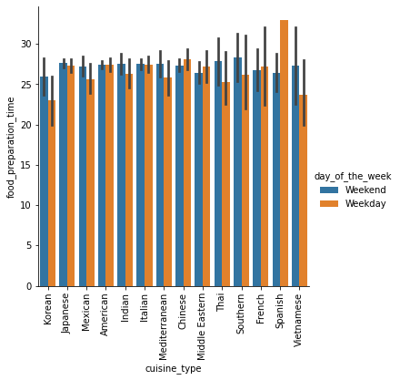

```python
sns.catplot(x='cuisine_type', y='food_preparation_time', data=df, kind="bar", hue='day_of_the_week')
plt.xticks(rotation=90)
plt.show()
```

#### Observation:

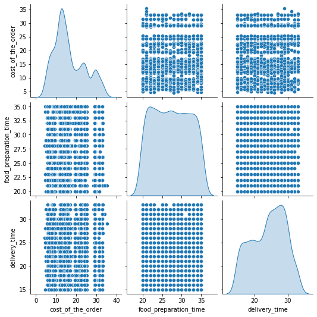

```python
sns.pairplot(data=df[num_var], diag_kind="kde");
```

#### Observation:

- *Given the pairplots above, there does not seem to be a strong relationship between the numeric variables, cost of the order, food prep time, and delivery time.*

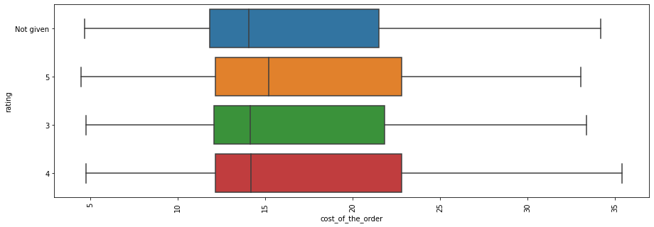

```python
# Find correlation with rating and total cost of the order.

plt.figure(figsize=(15,5))
sns.boxplot(data=df, x='cost_of_the_order', y='rating')
plt.xticks(rotation=90);
```

#### Observation:

- *Of the orders rated, it can be observed that the median rating of either a 3 rating or 4 rating costs roughly the same, while orders with a 5 rating costs slightly higher at 15 dollars.*

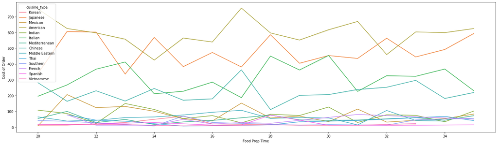

```python
# Find correlation with cuisine type and cost of order and food prep time.

plt.figure(figsize=(25,7))
sns.lineplot(data=df, x="food_preparation_time", y="cost_of_the_order",hue='cuisine_type', estimator='sum', ci=False)
plt.ylabel('Cost of Order')
plt.xlabel('Food Prep Time')
plt.show()
```

- *In the above graph, we attmpt to look at the cuisine type and any correlation between the cost of the order and the food prep time. We do not see any relevant pattern or correlation.*

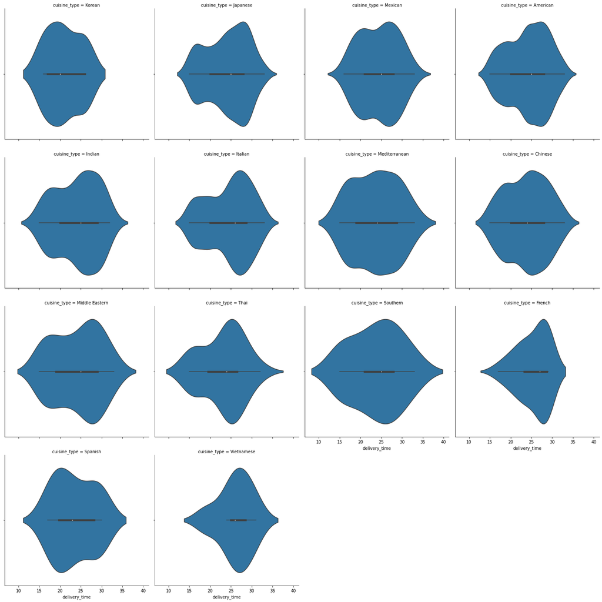

```python
# Dispersion of delivery time for each of the different cuisine types.

sns.catplot(x='delivery_time', col='cuisine_type', data=df, col_wrap=4, kind="violin")
plt.show()
```

#### Observation:

- *When we compare the delivery times for the different cuisine types, there is not a significant difference in that the majority of deliveries fall between 22 to 27 minutes.*

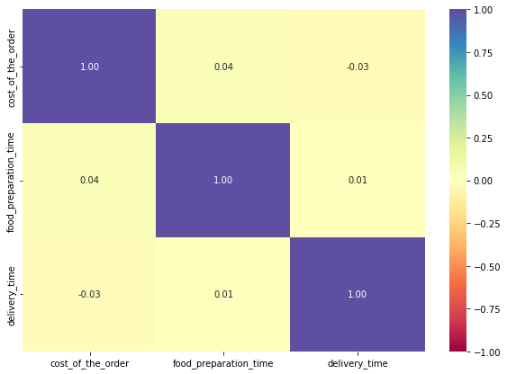

```python
# Check for correlation among all numerical variables:
num_var = ['cost_of_the_order','food_preparation_time', 'delivery_time']

corr = df[num_var].corr()

# plot a heat map

plt.figure(figsize = (10,7))
sns.heatmap(corr, annot=True, vmin=-1, vmax=1, fmt=".2f",cmap="Spectral")
plt.show()
```

#### Observation:

```python
df['rating'].unique()
```

```
array(['Not given', '5', '3', '4'], dtype=object)
```

```python
df['rating'].apply(type).value_counts()
```

```
<class 'str'>    1898
Name: rating, dtype: int64
```

```python
# We first change 'Not given' in this array to nan.
df['rating'] = df['rating'].replace(['Not given'],np.nan)

# Then change the array to data type float.
df['rating'] = df['rating'].astype(float)
```

```python
df.info()
```

```
<class 'pandas.core.frame.DataFrame'>
RangeIndex: 1898 entries, 0 to 1897
Data columns (total 9 columns):
 #   Column                 Non-Null Count  Dtype
---  ------                 --------------  -----
 0   order_id               1898 non-null   int64
 1   customer_id            1898 non-null   int64
 2   restaurant_name        1898 non-null   object
 3   cuisine_type           1898 non-null   object
 4   cost_of_the_order      1898 non-null   float64
 5   day_of_the_week        1898 non-null   object
 6   rating                 1162 non-null   float64
 7   food_preparation_time  1898 non-null   int64
 8   delivery_time          1898 non-null   int64
dtypes: float64(2), int64(4), object(3)
memory usage: 133.6+ KB
```

#### *Rating is now a float with the previous entry of "Not given" changed to "NaN", or "Not a Number".*

```python
df
```

|  | order_id | customer_id | restaurant_name | cuisine_type | cost_of_the_order | day_of_the_week | rating | food_preparation_time | delivery_time |
| --- | --- | --- | --- | --- | --- | --- | --- | --- | --- |
| 0 | 1477147 | 337525 | Hangawi | Korean | 30.75 | Weekend | NaN | 25 | 20 |
| 1 | 1477685 | 358141 | Blue Ribbon Sushi Izakaya | Japanese | 12.08 | Weekend | NaN | 25 | 23 |
| 2 | 1477070 | 66393 | Cafe Habana | Mexican | 12.23 | Weekday | 5.0 | 23 | 28 |
| 3 | 1477334 | 106968 | Blue Ribbon Fried Chicken | American | 29.20 | Weekend | 3.0 | 25 | 15 |
| 4 | 1478249 | 76942 | Dirty Bird to Go | American | 11.59 | Weekday | 4.0 | 25 | 24 |
| ... | ... | ... | ... | ... | ... | ... | ... | ... | ... |
| 1893 | 1476701 | 292602 | Chipotle Mexican Grill $1.99 Delivery | Mexican | 22.31 | Weekend | 5.0 | 31 | 17 |
| 1894 | 1477421 | 397537 | The Smile | American | 12.18 | Weekend | 5.0 | 31 | 19 |
| 1895 | 1477819 | 35309 | Blue Ribbon Sushi | Japanese | 25.22 | Weekday | NaN | 31 | 24 |
| 1896 | 1477513 | 64151 | Jack's Wife Freda | Mediterranean | 12.18 | Weekday | 5.0 | 23 | 31 |
| 1897 | 1478056 | 120353 | Blue Ribbon Sushi | Japanese | 19.45 | Weekend | NaN | 28 | 24 |

1898 rows × 9 columns

#### *There are 588 rows that contain a rating value of 5:*

```python
cat_cols = ['rating',]
for column in cat_cols:
    print(df[column].value_counts())
```

```
5.0    588
4.0    386
3.0    188
Name: rating, dtype: int64
```

```python
temp_df_groupby_rating = pd.DataFrame(df.groupby(['restaurant_name'])['rating'].mean()).reset_index()
temp_df_groupby_rating[temp_df_groupby_rating['rating']>4]
```

|  | restaurant_name | rating |
| --- | --- | --- |
| 0 | 'wichcraft | 5.000000 |
| 1 | 12 Chairs | 4.500000 |
| 3 | 67 Burger | 5.000000 |
| 5 | Amma | 4.500000 |
| 7 | Anjappar Chettinad | 5.000000 |
| ... | ... | ... |
| 171 | Yama 49 | 5.000000 |
| 172 | Yama Japanese Restaurant | 4.500000 |
| 175 | da Umberto | 5.000000 |
| 176 | ilili Restaurant | 4.153846 |
| 177 | indikitch | 4.500000 |

110 rows × 2 columns

```python
df.groupby(['restaurant_name']).agg({'rating':[np.mean,sum]}).reset_index()
```

|  | restaurant_name | rating mean | rating sum |
| --- | --- | --- | --- |
| 0 | 'wichcraft | 5.000000 | 5.0 |
| 1 | 12 Chairs | 4.500000 | 9.0 |
| 2 | 5 Napkin Burger | 4.000000 | 8.0 |
| 3 | 67 Burger | 5.000000 | 5.0 |
| 4 | Alidoro | NaN | 0.0 |
| ... | ... | ... | ... |
| 173 | Zero Otto Nove | 4.000000 | 4.0 |
| 174 | brgr | 3.000000 | 3.0 |
| 175 | da Umberto | 5.000000 | 5.0 |
| 176 | ilili Restaurant | 4.153846 | 54.0 |
| 177 | indikitch | 4.500000 | 9.0 |

178 rows × 3 columns

```python
# Orders which cost greater than 20 dollars.

df.loc[df['cost_of_the_order']>20]
```

|  | order_id | customer_id | restaurant_name | cuisine_type | cost_of_the_order | day_of_the_week | rating | food_preparation_time | delivery_time |
| --- | --- | --- | --- | --- | --- | --- | --- | --- | --- |
| 0 | 1477147 | 337525 | Hangawi | Korean | 30.75 | Weekend | NaN | 25 | 20 |
| 3 | 1477334 | 106968 | Blue Ribbon Fried Chicken | American | 29.20 | Weekend | 3.0 | 25 | 15 |
| 5 | 1477224 | 147468 | Tamarind TriBeCa | Indian | 25.22 | Weekday | 3.0 | 20 | 24 |
| 12 | 1476966 | 129969 | Blue Ribbon Fried Chicken | American | 24.30 | Weekend | 5.0 | 23 | 17 |
| 17 | 1477373 | 139885 | Blue Ribbon Sushi Izakaya | Japanese | 33.03 | Weekend | NaN | 21 | 22 |
| ... | ... | ... | ... | ... | ... | ... | ... | ... | ... |
| 1884 | 1477437 | 304993 | Shake Shack | American | 31.43 | Weekend | 3.0 | 31 | 24 |
| 1885 | 1477550 | 97324 | Shake Shack | American | 29.05 | Weekday | 4.0 | 27 | 29 |
| 1892 | 1477473 | 97838 | Han Dynasty | Chinese | 29.15 | Weekend | NaN | 29 | 21 |
| 1893 | 1476701 | 292602 | Chipotle Mexican Grill $1.99 Delivery | Mexican | 22.31 | Weekend | 5.0 | 31 | 17 |
| 1895 | 1477819 | 35309 | Blue Ribbon Sushi | Japanese | 25.22 | Weekday | NaN | 31 | 24 |

555 rows × 9 columns

```python
# Orders which cost greater than 5 dollars.

df.loc[df['cost_of_the_order']>5]
```

[output not shown]

1889 rows × 9 columns

```python
food_prep_data = {'food_preparation_time':[df['food_preparation_time']>30]}
print(food_prep_data)
```

```
{'food_preparation_time': [0       False
1       False
2       False
3       False
4       False
        ...
1893     True
1894     True
1895     True
1896    False
1897    False
Name: food_preparation_time, Length: 1898, dtype: bool]}
```

```python
delivery_time_data = {'delivery_time':[df['delivery_time']>30]}
print(delivery_time_data)
```

```
{'delivery_time': [0       False
1       False
2       False
3       False
4       False
        ...
1893    False
1894    False
1895    False
1896     True
1897    False
Name: delivery_time, Length: 1898, dtype: bool]}
```

```python
df = pd.DataFrame(columns=['food_preparation_time' + 'delivery_time'])

for i in range(1898):
  this_column = df.columns[i]
  df[this_column] = [i, i+1]

print(df)
```

[output not shown]

### **Question 16:** The company wants to analyze the delivery time of the orders on weekdays and weekends. How does the mean delivery time vary during weekdays and weekends? [2 marks]

```python
df.groupby(by = ['day_of_the_week'])['delivery_time'].mean()
```

```
day_of_the_week
Weekday    28.340037
Weekend    22.470022
Name: delivery_time, dtype: float64
```

#### Observation:

- *Average on weekdays for delivery time is 28 minutes, while on weekends it is 22 minutes.*

```python
df.groupby(by = ['cuisine_type','day_of_the_week'])['delivery_time'].mean()
```

```
cuisine_type    day_of_the_week
American        Weekday            28.248521
                Weekend            22.542169
Chinese         Weekday            28.826923
                Weekend            22.269939
French          Weekday            27.200000
                Weekend            24.615385
Indian          Weekday            27.625000
                Weekend            22.346939
Italian         Weekday            28.802198
                Weekend            22.705314
Japanese        Weekday            28.133333
                Weekend            22.519403
Korean          Weekday            26.000000
                Weekend            20.000000
Mediterranean   Weekday            28.785714
                Weekend            21.312500
Mexican         Weekday            28.250000
                Weekend            22.641509
Middle Eastern  Weekday            28.470588
                Weekend            21.750000
Southern        Weekday            29.500000
                Weekend            20.727273
Spanish         Weekday            28.000000
                Weekend            23.000000
Thai            Weekday            26.500000
                Weekend            22.266667
Vietnamese      Weekday            27.666667
                Weekend            25.000000
Name: delivery_time, dtype: float64
```

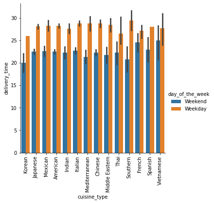

```python
sns.catplot(x='cuisine_type', y='delivery_time', data=df, kind="bar", hue='day_of_the_week')
plt.xticks(rotation=90)
plt.show()
```

### Recommendations:

- *It would be helpful to know date periods and when these deliveries occurred. It would be helfpul to also have additional but separate date periods, to compare seasonality (Example: JAN-MAR vs MAY-JUL), also if the dataset occurred near or around holidays. Data from such datasets could lend to opportunities around hiring, both for the restaurants and the company (managing the app to hire more drivers, etc.).*
- *Distance. If we could get distance data between customers who order and the restaurants from where they order, this is an opportunity to concentrate drivers who live closest to those restaurants and/or customers, respectively.*
- *There is opportunity to focus on low performing restaurants in which total orders are lower based on cuisine type. For instance restaurants offering Vietnamese cuisine, although not so popular in some areas, could consider either moving or opening more outlets in other areas of the city where there is a concentration of this ethnic group.*
- _There is opportunity to increase rating submissions by incentivizing discounted orders.
- *Although it was helpful to see a difference with numerical data comparing weekends and weekdays, it would be even more helpful if we could get data to compare each of the weekdays, Mondays through Fridays. There may be opportunities to focus on slow volume days, as well as peak volume days during the week. For example, the data provided us clear indications that delivery times take longer during weekdays. If we can identify which of the weekdays are busiest, a strategy could be to incentivize current drivers to work overtime or simply contract more drivers on these peakd days.*